# individual2

Armando Castillo

9/13/2020

```r
choco <- read.csv("https://raw.githubusercontent.com/xdaiISU/ds202materials/master/hwlabs/data/choco.csv")
str(choco)
```

```
## 'data.frame':    2312 obs. of  13 variables:
##  $ REF                 : int  2454 2458 2454 797 797 1015 1019 1011 1019 1011 ...
##  $ Company             : chr  "5150" "5150" "5150" "A. Morin" ...
##  $ Location            : chr  "U.S.A." "U.S.A." "U.S.A." "France" ...
##  $ Date                : int  2019 2019 2019 2012 2012 2013 2013 2013 2013 2013 ...
##  $ Bean_Origin         : chr  "Madagascar" "Dominican Republic" "Tanzania" "Peru" ...
##  $ Specific_Bean_Origin: chr  "Bejofo Estate, batch 1" "Zorzal, batch 1" "Kokoa Kamili, batch 1" "Peru" ...
##  $ Cocoa_Percent       : num  76 76 76 63 70 70 63 70 70 70 ...
##  $ Ingredients         : chr  "3- B,S,C" "3- B,S,C" "3- B,S,C" "4- B,S,C,L" ...
##  $ Characteristics1    : chr  "cocoa" "cocoa" "rich cocoa" "fruity" ...
##  $ Characteristics2    : chr  "blackberry" "vegetal" "fatty" "melon" ...
##  $ Characteristics3    : chr  "full body" "savory" "bready" "roasty" ...
##  $ Characteristics4    : chr  NA NA NA NA ...
##  $ Rating              : num  3.75 3.5 3.25 3.75 3.5 4 4 3.75 3.5 3.25 ...
```

## Searching for Best Chocolates

1. How are the ratings distributed? Create both a histogram and a boxplot and describe them. Don’t forget to mention outliers, if there are any.

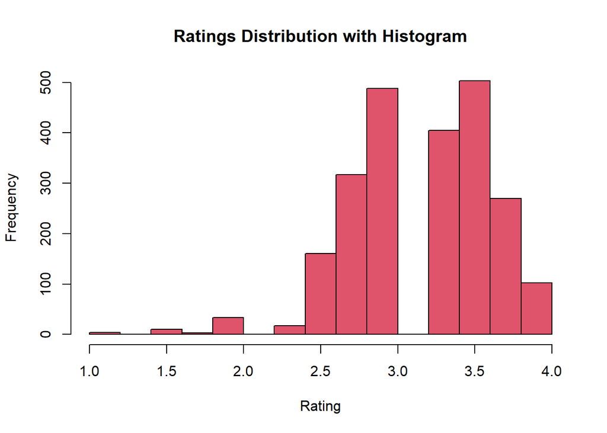

```r
hist(choco$Rating, main='Ratings Distribution with Histogram', xlab='Rating', col=26)
```

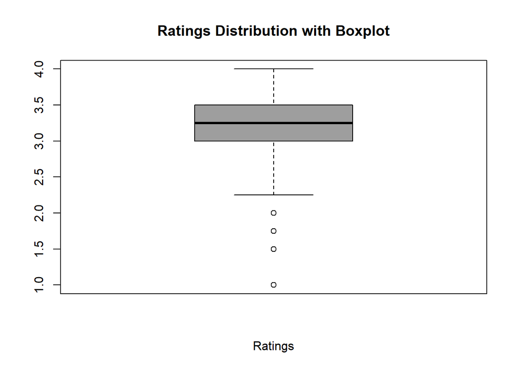

```r
boxplot(choco$Rating, main='Ratings Distribution with Boxplot', xlab='Ratings', col=40)
```

The histogram is left skewed with some outliers closer to the lower rating side from 1.0 to 2.0 The boxplot is also left skewed and has about 4 outliers on the lower end of the ratings

2. How does the number of ratings depend on the year? Draw a bar chart of the number of reports.

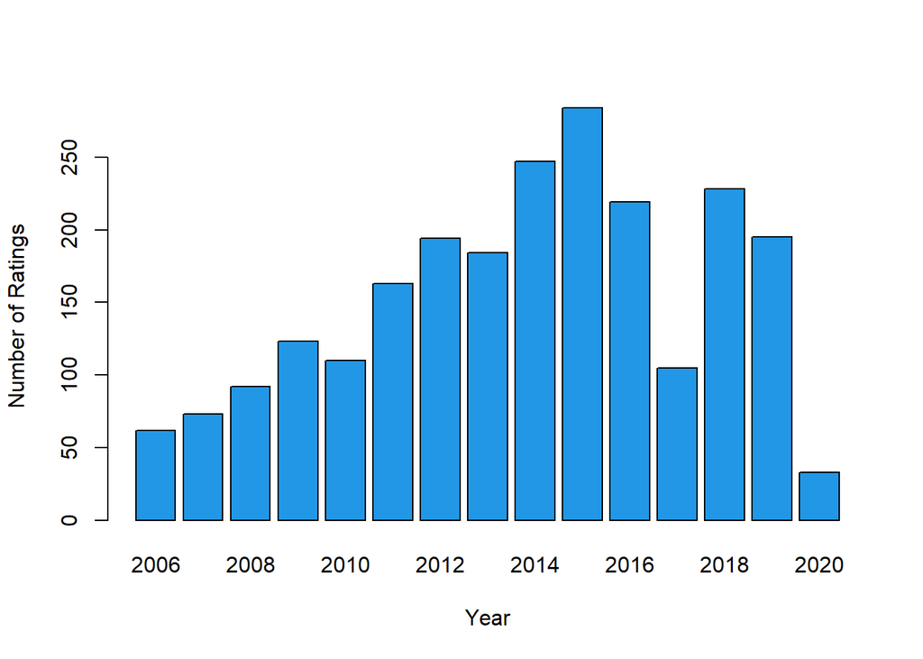

```r
countPerYear <- table(choco$Date)
barplot(countPerYear,  xlab='Year', ylab='Number of Ratings', col=60)
```

3. Do ratings depend on the cacao percentage of a chocolate bar? Create both numerical and graphical summaries, and explain.

```r
percent <- choco[c("Cocoa_Percent","Rating")]
summary(percent)
```

```
##  Cocoa_Percent        Rating
##  Min.   : 42.00   Min.   :1.000
##  1st Qu.: 70.00   1st Qu.:3.000
##  Median : 70.00   Median :3.250
##  Mean   : 71.65   Mean   :3.184
##  3rd Qu.: 75.00   3rd Qu.:3.500
##  Max.   :100.00   Max.   :4.000
```

```r
cor(choco$Cocoa_Percent, choco$Rating)
```

```
## [1] -0.1510178
```

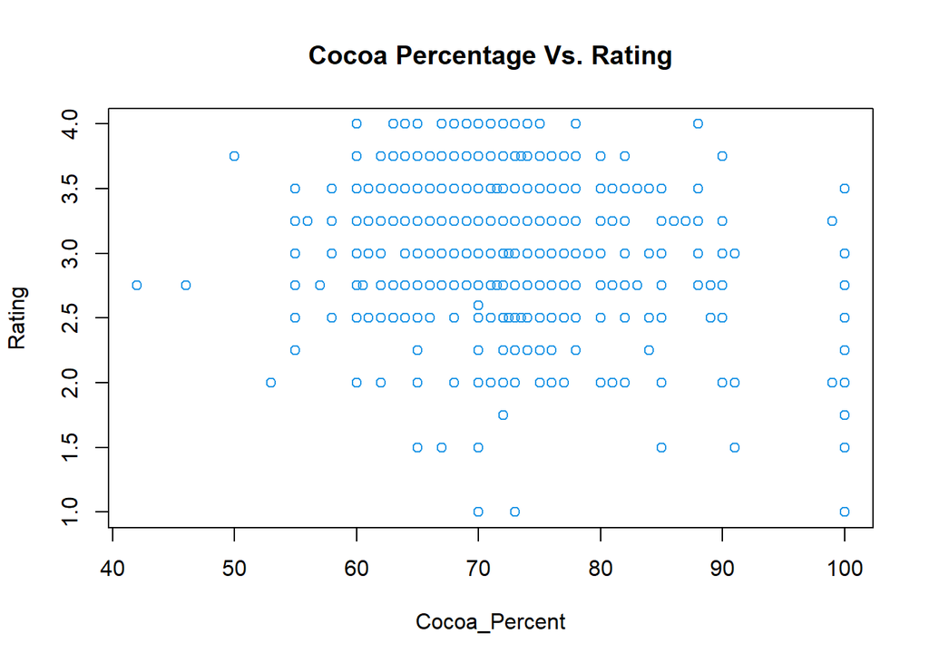

```r
plot(percent, col=100)
title(main="Cocoa Percentage Vs. Rating")
```

Based off the scatter plot and correlation coefficient of cocoa percentage and rating. Rating does not depend on cocoa percentage. The correlation between them is very low at -0.15 and there is no visual relationship in the scatter plot.

4. How do different characteristics of the chocolate compare? To elaborate, which characteristics tend to be more favorable and which ones are not? Create both numerical and graphical summaries, and explain.

```r
head(summary(factor(choco$Characteristics1)), n=5)
```

```
##  creamy   sandy intense   nutty   fatty
##     162     134      82      78      76
```

```r
head(summary(factor(choco$Characteristics2)), n=5)
```

```
##  sweet  nutty earthy  cocoa roasty
##    120     86     75     69     65
```

```r
head(summary(factor(choco$Characteristics3)), n=5)
```

```
##  cocoa  nutty roasty   sour earthy
##     96     71     70     65     50
```

```r
head(summary(factor(choco$Characteristics4)), n=5)
```

```
## acidic  apple banana  berry bitter
##      1      1      2      1      5
```

There are definitely top choices for first, second, and the third characteristic. Looking at the data, creamy and sandy beat out the rest to be the top characteristic for characteristic 1. Sweet and nutty are the top for characteristic 2. Cocoa and nutty along with roasty are all very close to the top for characteristic 3. Finally, for characteristic 4 it loos like there is minimal competition with small numbers. If we had to choice one it would be bitter.

5. Brainstorm two analyses you would like to perform with your teammate. Describe in plain language what comparisons are you making. Create suitable numerical and graphical summaries for your analyses. Describe the results.